# STT6300: Introduction

## About me

- B.S., M.S., and Ph.D. in Applied Statistics
- Worked in the WSU SCC for a tear
- Spent the last two as the lead Data Scientist over at the School of Aerospace Medicine
- Currently work in the Data Science Lab at AFIT

## What is statistics?

## Statistics

- The science of data collection and analysis!
- The sexier term is now *Data Science*

[figure not shown]

## Design

Before analyzing the data, the data needs to be collected. Thus, statistics also encompasses the science of collecting data.

- **Sampling design** is the branch of statistics that focuses on collecting observational data
- **Experimental design** is the branch of statistics that focuses on collecting data through experiments, like in a laboratory

## Biostatistics

- Statistics applied to biological experiments, especially in medicine, pharmacy, agriculture and fishery
- Has seen enormous growth in recent years
- Use in high-throughput data
- New biomedical technologies like **microarrays**, next generation **sequencers** (genomics) and **mass spectrometry** (proteomics) generate massive amounts of data
- Surge in new statistical methodology to deal with these "massive" data sets
- Thousands of statistical tests are often performed (false discovery rates)

## Statistical software

- [R](https://www.r-project.org/)
- [RStudio](https://www.rstudio.com/)

## Populations and samples

- The primary goal of statistics is to infer something about a **population** based on a **sample** obtained from the population (typically at random)
- Populations may be very large (or even hypothetically infinite in size)
- Often impossible or impractical to observe every object in the population
- With statistics we can make accurate statements about the population using a sample (even a very small one!)

## How many observations should one collect?

- Think of data as evidence
- The more data we have, the more information we have
- However, data collection can be expensive and time consuming (e.g., pharmaceutical studies)
- Determining "optimal" sample size is important in any study, and quite simple once all of the following are specified:
  - smallest effect of **clinical significance**
  - desired **power** (\(1 - \beta\)) and **significance level** (\(\alpha\))
  - distributions of the observables
  - whether a one- or two-sided test will be used

## Statistical models

The scientific question that one hopes to investigate using statistical analysis can usually be formalized using statistical models. We shall use the following example to illustrate a simple models.

```r
data(Animals, package = "MASS")  # brain and body weights for 28 species of land
head(Animals)                    # animals
```

```
##                     body brain
## Mountain beaver     1.35   8.1
## Cow               465.00 423.0
## Grey wolf          36.33 119.5
## Goat               27.66 115.0
## Guinea pig          1.04   5.5
## Dipliodocus     11700.00  50.0
```

## Statistical models

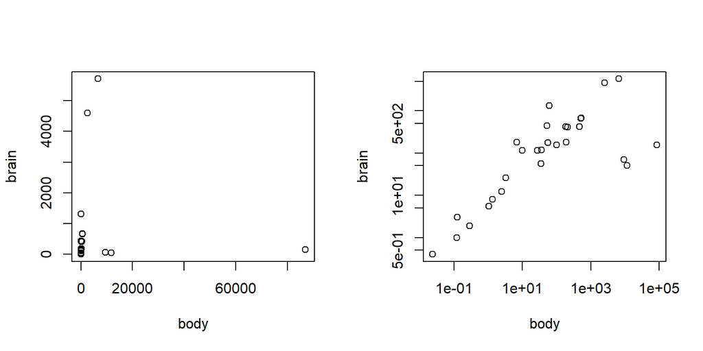

```r
par(mfrow = c(1, 2))  # setup to place the following plots side-by-side
plot(Animals)  # plot the first column (x-axis) vs. the second column (y-axis)
plot(Animals, log = "xy")  # transform both variables by taking the natural log
```

## Statistical models

```r
slr <- lm(log(brain) ~ log(body), data = Animals)  # fit a simple linear model
summary(slr)  # print a summary of the fitte model
```

```
##
## Call:
## lm(formula = log(brain) ~ log(body), data = Animals)
##
## Residuals:
##     Min      1Q  Median      3Q     Max
## -3.2890 -0.6763  0.3316  0.8646  2.5835
##
## Coefficients:
##             Estimate Std. Error t value Pr(>|t|)
## (Intercept)  2.55490    0.41314   6.184 1.53e-06 ***
## log(body)    0.49599    0.07817   6.345 1.02e-06 ***
## ---
## Signif. codes:  0 '***' 0.001 '**' 0.01 '*' 0.05 '.' 0.1 ' ' 1
##
## Residual standard error: 1.532 on 26 degrees of freedom
## Multiple R-squared:  0.6076, Adjusted R-squared:  0.5925
## F-statistic: 40.26 on 1 and 26 DF,  p-value: 1.017e-06
```

## Statistical models

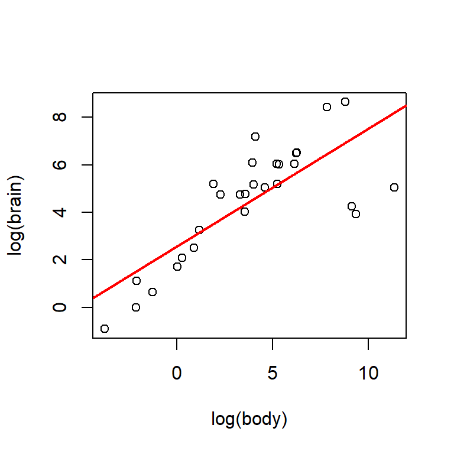

```r
plot(log(brain) ~ log(body), data = Animals)  # plot the data
abline(slr, col = "red", lwd = 2)  # plot the fitted regression line
```

## Statistical models

A simple formula to predict brain weight (g) from body weight (kg) using the previously fitted regression model is

\[ \hat{\log\left(brain\right)} = 2.555 + 0.496 \log\left(body\right) \]

## Statistic

- A statistic is a number that is computed from the data in a (random) sample
- They can be computed by plugging the data into a formula that does not require knowing the true parameter values of the population of interest
- One of the simplest examples of a statistic is the arithmetic mean: \[\bar{x} = \frac{x_1 + \dots + x_n}{n}\]
- Other examples include the median, variance, MAD, IQR, and the estimated intercept/slope of a regression line